# Linear models

## Learning outcomes

- The linear model.
- Using RStudio to fit linear models.
- Prediction.
- Assumptions of the linear model.

## Example: Donkeys

## Example: 385 Moroccan donkeys.

| Variable | Description |
| --- | --- |
| Sex | Sex (Female/Male) |
| Age | Age (years) |
| Bodywt | Weight (kg) |
| Heartgirth | Girth at the heart (cm) |
| Umbgirth | Girth at the umbilicus (cm) |
| Length | Length from elbow to hind (cm) |
| Height | Height to the withers (cm) |

## Relationships: Donkeys

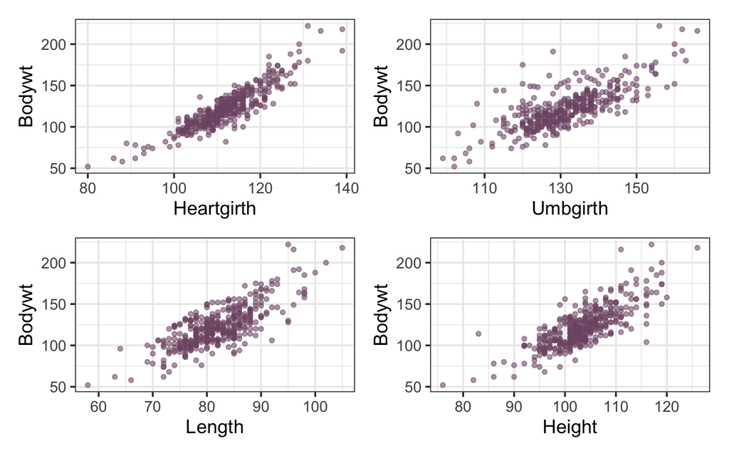

## Relationships: Donkeys

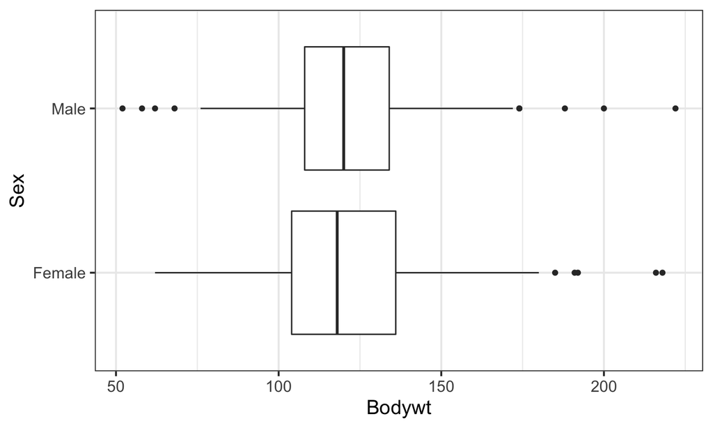

## Relationships: Donkeys

- There are reasonably strong increasing relationships between body weight and hearth girth, umbilical girth, length and height.
- There doesn’t seem much difference between the sexes.
- The *strongest* relationship is with heart girth. **Why?**
- We’ll look at **modelling** this relationship using a straight line.

## The Linear Model

## Linear modelling

- Try to explain the variation in one measurement using other measurements.
- Key is to model the **mean** of one variable conditional on the values of other variables.
- Once we have a model, we can use that model for **prediction** or for quantifying the extent of the relationship.

## Linear modelling

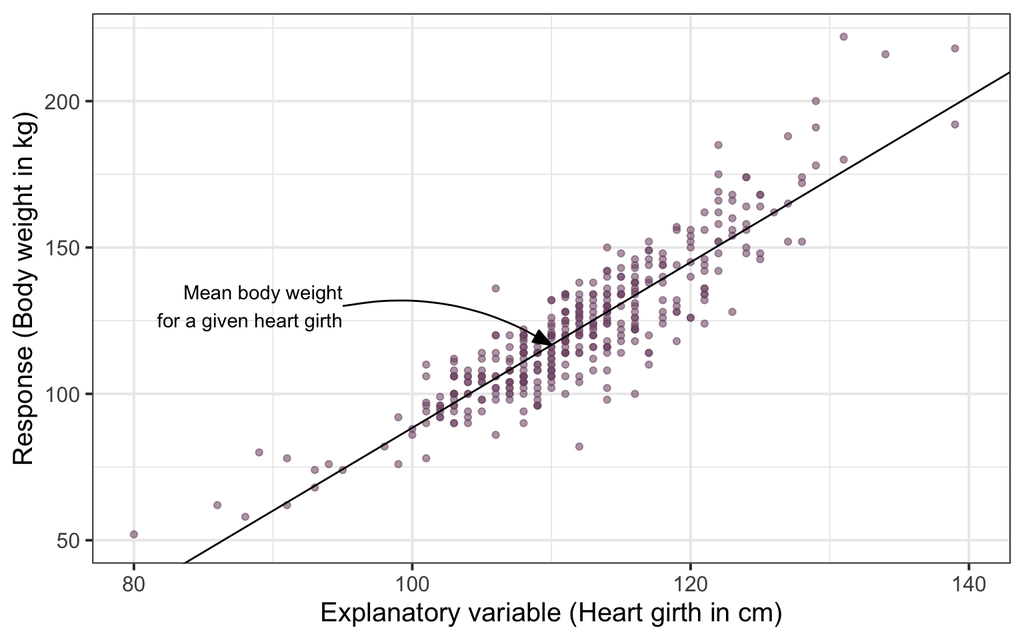

## Linear modelling

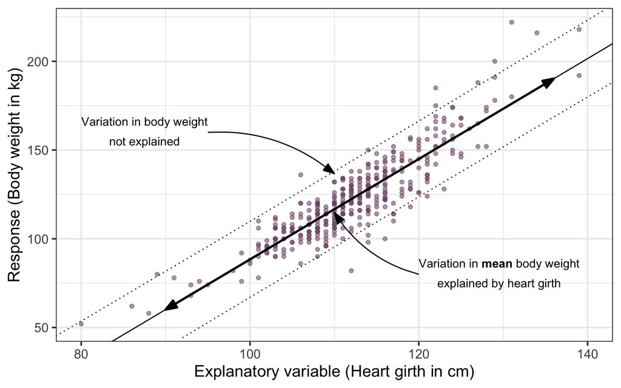

## Definitions

- The **response**, or **dependent variable**, is the numeric variable we wish to model (the \(y\) variable).
- The **explanatory** variable(s), or **predictors**, **covariates**, or **independent variables** are the \(x\) variables we use to explain the response. They needn’t be numeric.
- The **regression line** or **linear model** is the way we relate \(y\) to the explanatory variables \(x\).
- For the simple case of a single numeric predictor, the equation is \[ \mathsf{mean}(y) = \alpha + \beta x \] where \(\alpha\) is the **intercept** or **baseline**, and \(\beta\) is the **slope**, or **gradient**.

## Definitions

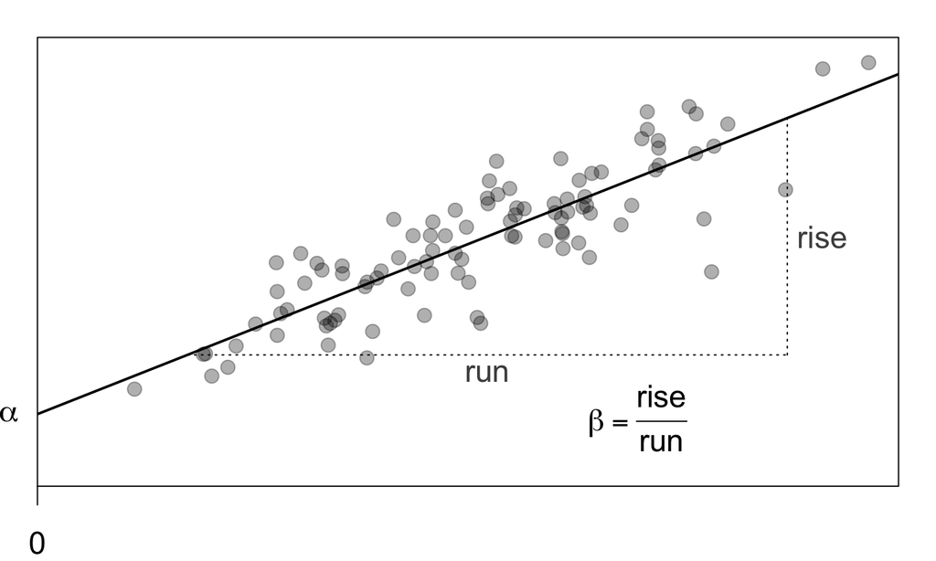

## Sample versus Population

- Combined, the \(\alpha\) and \(\beta\) are known as **coefficients** of the linear model in the population. Linear modelling is the process of fitting this model to data, where we **estimate** these coefficients.
- We only ever have a sample of data, thus our estimates are sample statistics, which we hope will be representative of the true parameters \(\alpha\) and \(\beta\) in the population.

## Estimation of parameters

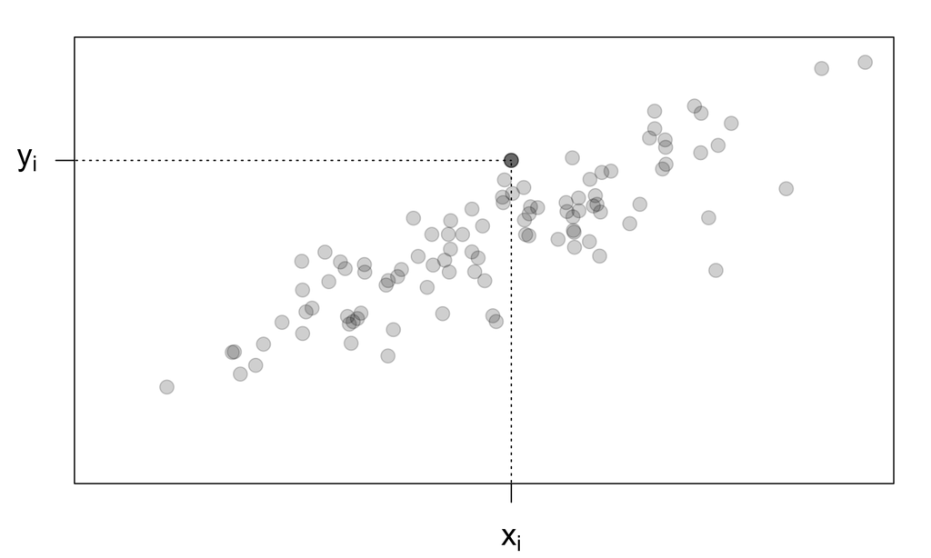

## Estimation of parameters

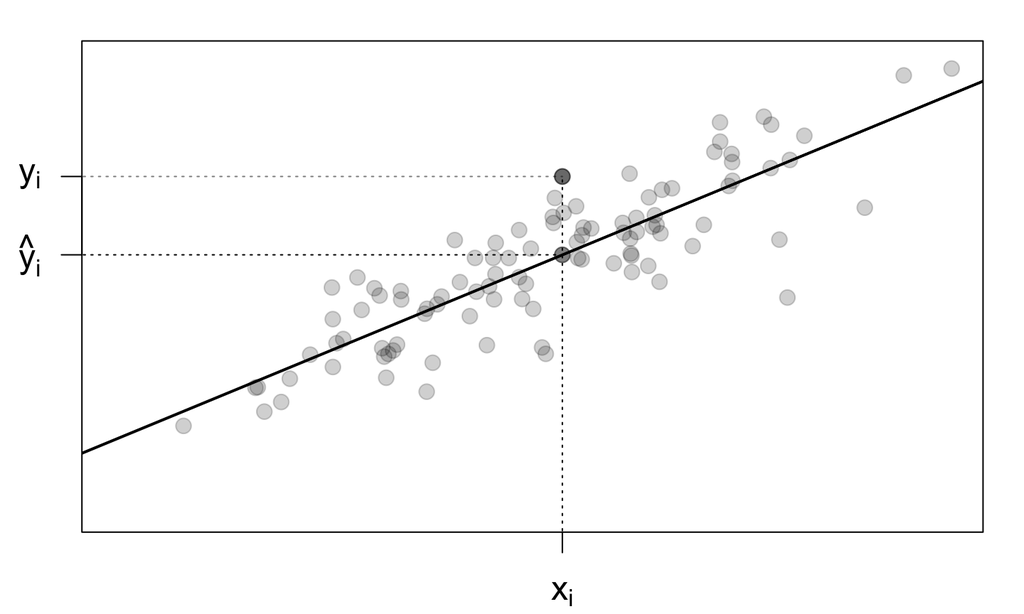

## Estimation of parameters

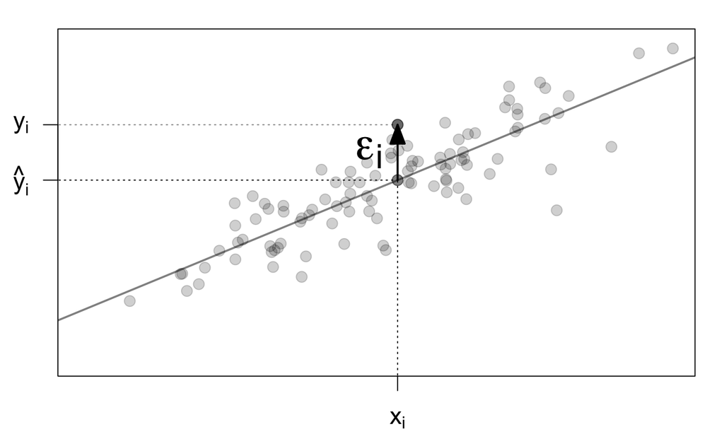

## Estimation of parameters

- For each point \(x_i\) we have the corresponding estimated value \(\hat{y}_i = \alpha + \beta x_i\).
- The difference between the real \(y_i\) and fitted \(\hat{y}_i\) is the **residual** \(\epsilon_i = y_i - \hat{y}_i\).
- We find the optimal \(\alpha\) and \(\beta\) by minimising the variance of the residuals, subject to their mean being 0.
- This is called **least squares** estimation as the formula for variance contains a sum of squares \[ \begin{aligned} \mathsf{var}(\epsilon_i) &= \frac{1}{n}\sum_{i=1}^n (\epsilon_i - 0)^2\\ &= \frac{1}{n}\sum_{i=1}^n (y_i - (\alpha + \beta x_i))^2 \end{aligned} \]

## Estimation of parameters

- We minimise the **residual variance** \[ \mathsf{Var}_\mathsf{res} = \frac{1}{n}\sum_{i=1}^n (y_i - (\alpha + \beta x_i))^2 \]
- The values of \(\alpha\) and \(\beta\), found using calculus, are **least squares estimates**.
- We often put hats on them (\(\hat{\alpha}\), \(\hat{\beta}\)) to help us remember that they’re sample statistics and not the true values from the population.
- We’ll add some assumptions later so we can relate our estimates to the population parameters.

## Estimation of parameters

[interactive chart not shown]

## Linear models in RStudio

## Linear models in RStudio

```r
mod <- lm(Bodywt ~ Heartgirth, data=donkey)
summary(mod)
```

## Linear models in RStudio

```
Call:
lm(formula = Bodywt ~ Heartgirth, data = donkey)

Residuals:
    Min      1Q  Median      3Q     Max
-40.343  -6.829   0.486   6.432  45.909

Coefficients:
              Estimate Std. Error t value Pr(>|t|)
(Intercept) -194.48580    7.99203  -24.34   <2e-16 ***
Heartgirth     2.82883    0.07118   39.74   <2e-16 ***
---
Signif. codes:  0 '***' 0.001 '**' 0.01 '*' 0.05 '.' 0.1 ' ' 1

Residual standard error: 10.83 on 383 degrees of freedom
Multiple R-squared:  0.8048,    Adjusted R-squared:  0.8043
F-statistic:  1580 on 1 and 383 DF,  p-value: < 2.2e-16
```

## Linear models in RStudio

- The `Estimate` column gives us the values of our coefficients.
  - The linear model equation would be \[ \mathsf{Body weight} = -194.5 + 2.83 \times \mathsf{Heart girth} \]
  - The estimate for `Heartgirth` means a 1 unit increase in heart girth corresponds to a 2.83 unit increase in mean body weight.
- The `Std. Error` column is the standard error of our estimates. We can use this to find confidence intervals.
  - For heart girth, we’re 95% confident that the coefficient of heartgirth is within \[ 2.83 \pm 2 \times 0.07 = (2.69, 2.97). \]

## Linear models in RStudio

- The `t value` column is the test statistic for the hypothesis that the coefficient is 0.
- The `Pr(>|t|)` column is the P-value for this hypothesis test.
- This is equivalent to asking “Does body weight depend on heart girth?”
- In this case, the P-value is very small, so there is very little chance that we’d observe an estimate as large as 2.83 if there was no relationship between body weight and heart girth in the population.
- Our conclusion would be that body weight does depend on heart girth.

## Linear models in RStudio

- The `Multiple R-squared` value is the proportion of variation in body weight explained by the model (i.e. explained by heart girth). \[ \begin{aligned} R^2 &= \frac{\mathsf{Variance\ Explained}}{\mathsf{Total\ Variance}} = \frac{\mathsf{Total\ Variance} - \mathsf{Residual\ Variance}}{\mathsf{Total\ Variance}}\\ &= \frac{\sigma_\mathsf{Y}^2 - \sigma_\mathsf{res}^2}{\sigma_\mathsf{Y}^2} \end{aligned} \]
- A high \(R^2\) value suggests that the model explains a lot of the variation of the outcome variable.
- i.e. Once you know the value of the heartgirth, you have a much lower range of potential values for the body weight.

## \(R^2\) for Donkeys

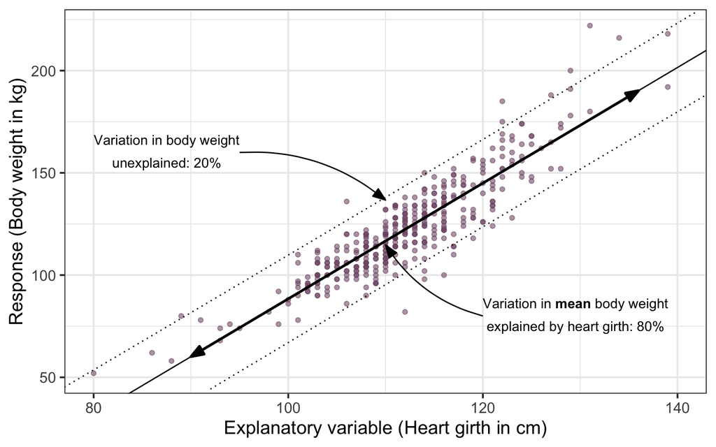

## Linear models in RStudio

- The `p-value` for the model (last line) is testing whether **anything** in the model helps explain body weight.
- Same as P-value for heart girth in this case, as only thing in the model.
- In models with more than one covariate, it will be assessing whether any of them help explain the outcome variable.

## Prediction

- We can predict the mean of \(y\) for any given value of \(x\) by just substituting values into the estimated linear model equation. e.g. for \(\mathsf{Heartgirth}=120\):

  \[ \begin{aligned} \mathsf{Body weight} &= -194.5 + 2.83 \times \mathsf{Heart girth}\\ & = -194.5 + 2.83 \times 120\\ & = 145 \end{aligned} \]
- In RStudio we can use the `predict` function for this:

```r
predict(mod, newdata = data.frame(Heartgirth=120))
```

```
       1
144.9736
```

## Prediction in RStudio

- We can utilise the standard errors of our estimates to give uncertainty for the predicted **mean**. This is a **confidence interval**.

  ```r
  new.data <- data.frame(Heartgirth=120)
  predict(mod, new.data, interval="confidence")
  ```

  ```
         fit      lwr      upr
    1 144.9736 143.4156 146.5315
  ```

- We can combine this with the variance of the residuals to give a prediction for the spread of individual values. This is a **prediction interval**.

  ```r
  predict(mod, new.data, interval="prediction")
  ```

  ```
         fit      lwr      upr
    1 144.9736 123.6144 166.3327
  ```

## Prediction in RStudio: Two at once

```r
new.data <- data.frame(Heartgirth=c(100,120))
predict(mod, new.data, interval="confidence")
```

```
        fit       lwr       upr
1  88.39699  86.39543  90.39855
2 144.97355 143.41560 146.53151
```

```r
predict(mod, new.data, interval="prediction")
```

```
        fit       lwr      upr
1  88.39699  67.00096 109.7930
2 144.97355 123.61445 166.3327
```

## Prediction

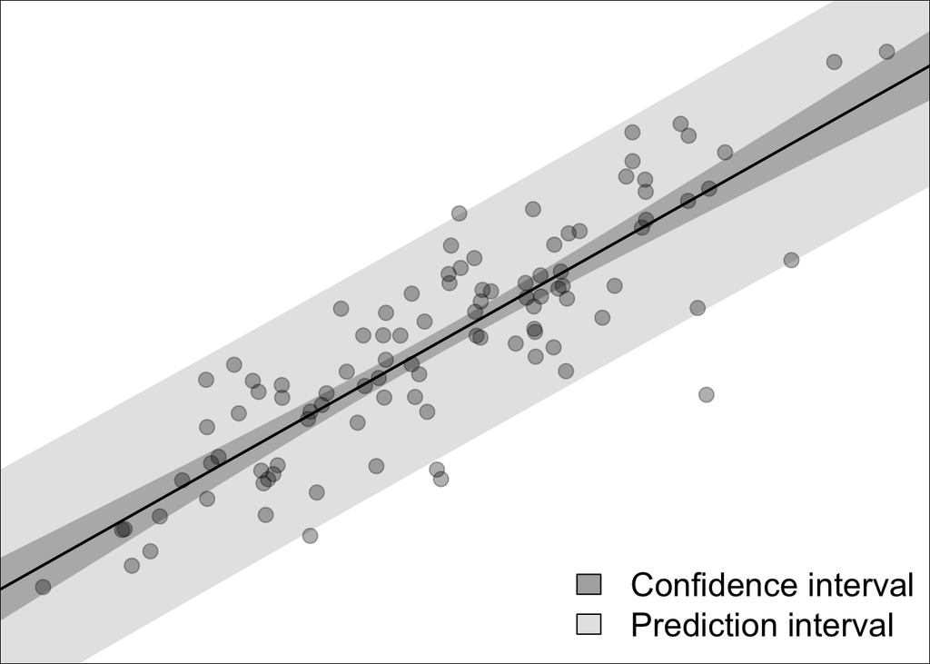

## Assumptions

## Assumptions of linear models

**L**inearity

- Residuals don’t depend on \(x\). The trend is correctly modelled.

**I**ndependence

- Residuals don’t depend on each other.

**N**ormality

- Residuals are distributed normally.

**E**qual variance

- Residuals have constant variance. The variation doesn’t change as we move along the trend.

\[ \epsilon_i \mathop{\sim}\limits_\mathsf{iid} \mathsf{Normal}(0, \sigma^2) \]

## Sampling distribution of our estimates

- As long as our assumptions hold then \(\hat\alpha\) and \(\hat\beta\) both have \(t\) distributions.
- We won’t bother with the equations for them, other than to note:
  - The estimates \(\hat\alpha\) and \(\hat\beta\) are **unbiased**, i.e. \[ \mathsf{mean}(\hat\alpha) = \alpha, \qquad \mathsf{mean}(\hat\beta) = \beta \]
  - The standard errors of \(\hat\alpha\) and \(\hat\beta\) decrease with \(n\) in the same way that the standard error of the sample mean decreases with \(n\).
  - We can test hypotheses about \(\alpha\) and \(\beta\) using these distributions.

## Importance of assumptions

- **Linearity** is the most important. Does the form of your model equation make sense?
- **Independence**. Do you have clustering of observations? Depends on data collection. Standard errors might be wrong.
- **Normality**. This is the least important due to the central limit theorem that says it will hold anyway! More important for prediction intervals than model estimates.
- **Equal variance**. Usually OK if linearity is OK. If not, standard errors might be wrong.

## Checking the assumptions

- We can check the linear model assumptions by producing **diagnostic plots** of the model.
- Using these, we can assess linearity, normality, and equal variance, but we usually can’t assess independence without using other information from the data (such as how it was collected).
- In addition, we can also see whether there are outliers in the data that have undue **influence** on our model fit.
- In RStudio, we can use `plot(model)` to get diagnostic plots.

*A log transformation often fixes linearity or unequal variance.*

## Diagnostic plots: Residuals versus fits

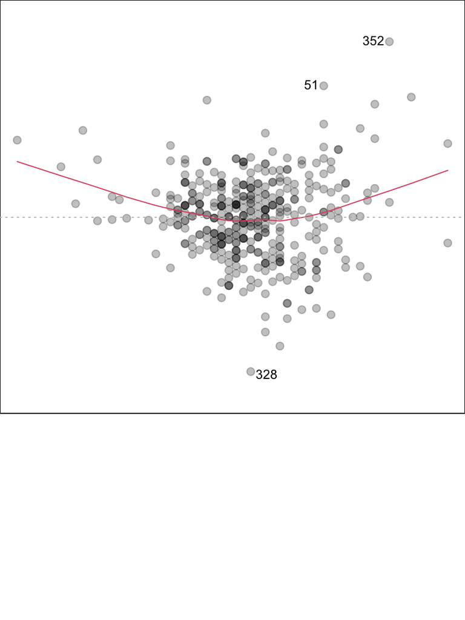

- Allows us to assess **linearity**.
- There should be no curve.
- Also allows assessing **equal variance**.
- The points shouldn’t fan out.
- When either of these fail, a log transform of \(y\) and/or \(x\) often straightens things out.

## Residuals versus fits

[interactive chart not shown]

## Diagnostic plots: Normal Q-Q plot

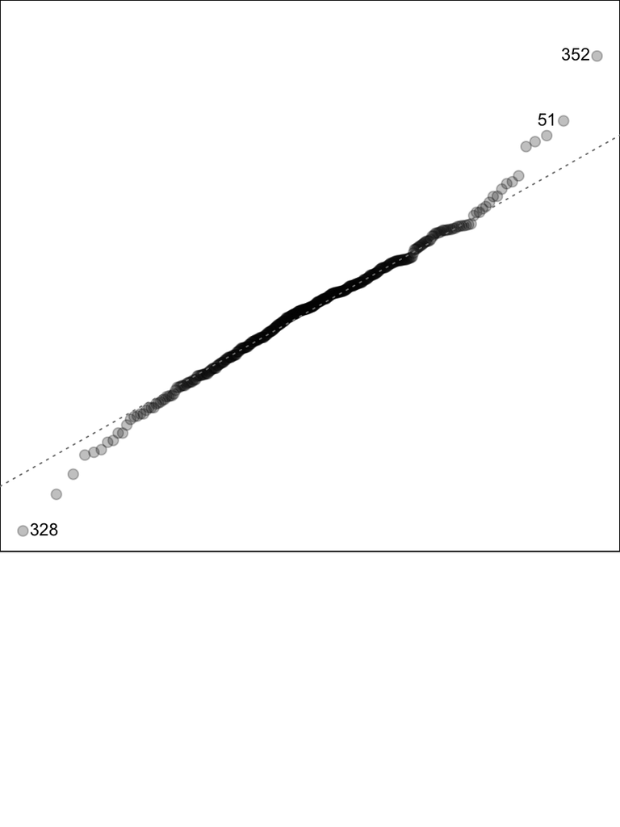

- Allows us to assess **normality**.
- Ideally the points will lie on the straight line.
- A slight S shaped curve is OK.
- Central limit theorem means this can generally be ignored.

## Diagnostic plots: Scale-location plot

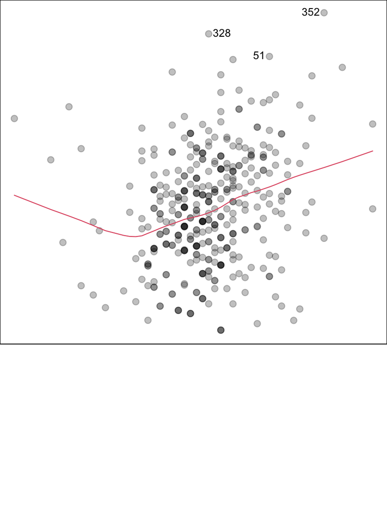

- Allows us to assess **equal variance**.
- Ideally should not be increasing or decreasing.
- Residuals versus fit often tells you this just as well.

## Diagnostic plots: Residuals versus Leverage

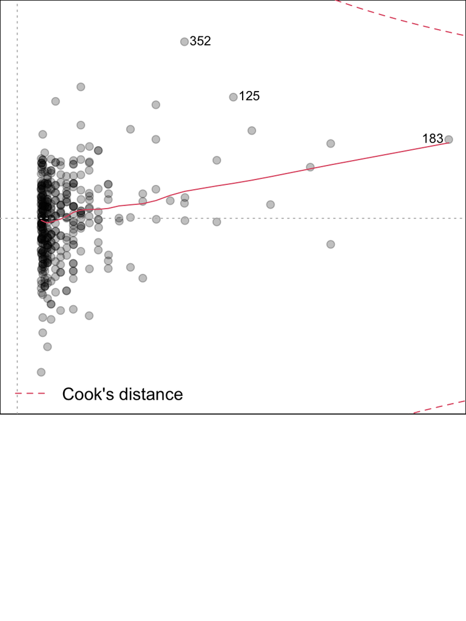

- Allows us to look for **influential outliers**.
- Points should ideally be inside red bands (Cook’s distance) at 0.5.
- Points outside Cook’s distance of 1 have excessive influence.

## Influential outliers

- Points can be outliers in two ways:
  - They can have extreme \(x\) values compared to the rest of the data. Such points are said to have high **leverage**.
  - They can have extreme \(y\) values, given their \(x\) value (i.e. a large residual.)
- Points have large **influence** if they exhibit both these properties.
- **Cook’s distance** is a measure of influence. Cook’s distance larger than 1 means the points have large influence on the model fit. Removing these points may change the model quite a bit.

## Influential outliers

[interactive chart not shown]

## Summary

- The residuals vs fitted plot should be looked at first. If you see curvature or increasing scatter from left to right, try a log transform and re-fit the model.
- Next look at residuals vs leverage. If you have influential outliers then look at the effect of removing those observations.